# w_10_d_2_diamond

Seàn M. Cusick

15/02/2022

# MVP

## Task 1

Load the `diamonds.csv` data set and undertake an initial exploration of the data.

### Variable Key

[Via Kaggle](https://www.kaggle.com/shivam2503/diamonds/)

| Variable | Description |
| --- | --- |
| price | price in US dollars ($326–$18,823) |
| carat | weight of the diamond (0.2–5.01) |
| cut | quality of the cut (Fair, Good, Very Good, Premium, Ideal) |
| color | diamond colour, from J (worst) to D (best) |
| clarity | a measurement of how clear the diamond is (I1 (worst), SI2, SI1, VS2, VS1, VVS2, VVS1, IF (best)) |
| x | length in mm (0–10.74) |
| y | width in mm (0–58.9) |
| z | depth in mm (0–31.8) |
| depth | total depth percentage = z / mean(x, y) = 2 * z / (x + y) (43–79) |
| table | width of top of diamond relative to widest point (43–95) |

### Summary

No `NA`s,

```r
summary(diamonds)
```

```
##        x1            carat            cut               color
##  Min.   :    1   Min.   :0.2000   Length:53940       Length:53940
##  1st Qu.:13486   1st Qu.:0.4000   Class :character   Class :character
##  Median :26971   Median :0.7000   Mode  :character   Mode  :character
##  Mean   :26971   Mean   :0.7979
##  3rd Qu.:40455   3rd Qu.:1.0400
##  Max.   :53940   Max.   :5.0100
##    clarity              depth           table           price
##  Length:53940       Min.   :43.00   Min.   :43.00   Min.   :  326
##  Class :character   1st Qu.:61.00   1st Qu.:56.00   1st Qu.:  950
##  Mode  :character   Median :61.80   Median :57.00   Median : 2401
##                     Mean   :61.75   Mean   :57.46   Mean   : 3933
##                     3rd Qu.:62.50   3rd Qu.:59.00   3rd Qu.: 5324
##                     Max.   :79.00   Max.   :95.00   Max.   :18823
##        x                y                z
##  Min.   : 0.000   Min.   : 0.000   Min.   : 0.000
##  1st Qu.: 4.710   1st Qu.: 4.720   1st Qu.: 2.910
##  Median : 5.700   Median : 5.710   Median : 3.530
##  Mean   : 5.731   Mean   : 5.735   Mean   : 3.539
##  3rd Qu.: 6.540   3rd Qu.: 6.540   3rd Qu.: 4.040
##  Max.   :10.740   Max.   :58.900   Max.   :31.800
```

### Head

```r
head(diamonds) %>%
  knitr::kable()
```

| x1 | carat | cut | color | clarity | depth | table | price | x | y | z |
| --- | --- | --- | --- | --- | --- | --- | --- | --- | --- | --- |
| 1 | 0.23 | Ideal | E | SI2 | 61.5 | 55 | 326 | 3.95 | 3.98 | 2.43 |
| 2 | 0.21 | Premium | E | SI1 | 59.8 | 61 | 326 | 3.89 | 3.84 | 2.31 |
| 3 | 0.23 | Good | E | VS1 | 56.9 | 65 | 327 | 4.05 | 4.07 | 2.31 |
| 4 | 0.29 | Premium | I | VS2 | 62.4 | 58 | 334 | 4.20 | 4.23 | 2.63 |
| 5 | 0.31 | Good | J | SI2 | 63.3 | 58 | 335 | 4.34 | 4.35 | 2.75 |
| 6 | 0.24 | Very Good | J | VVS2 | 62.8 | 57 | 336 | 3.94 | 3.96 | 2.48 |

### Distribution

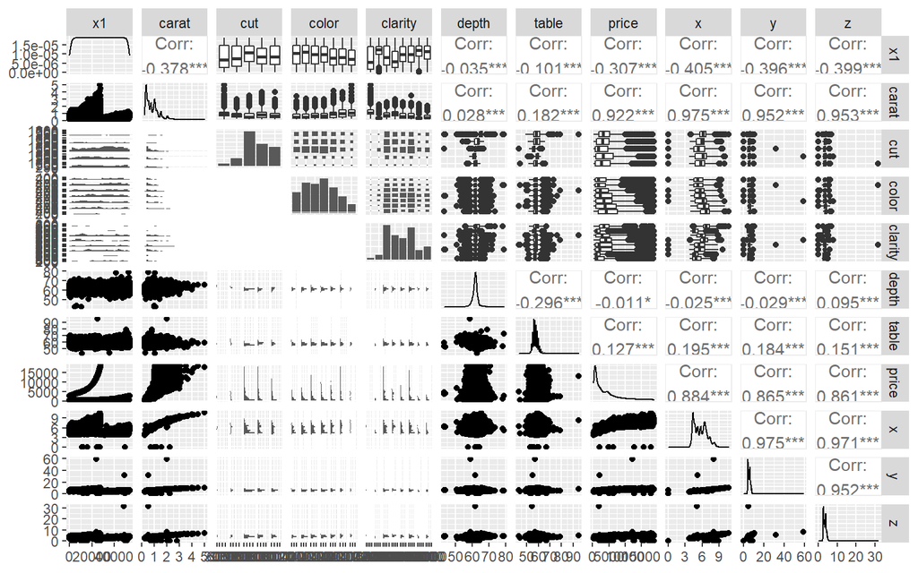

```r
  ggpairs(diamonds) +
  scale_color_viridis(discrete = TRUE,
                      option = "D") +
  scale_fill_viridis(discrete = TRUE)
```

## Task 2

We expect the `carat` of the diamonds to be strong correlated with the physical dimensions `x`, `y` and `z`. Use g`gpairs()` to investigate correlations between these four variables.

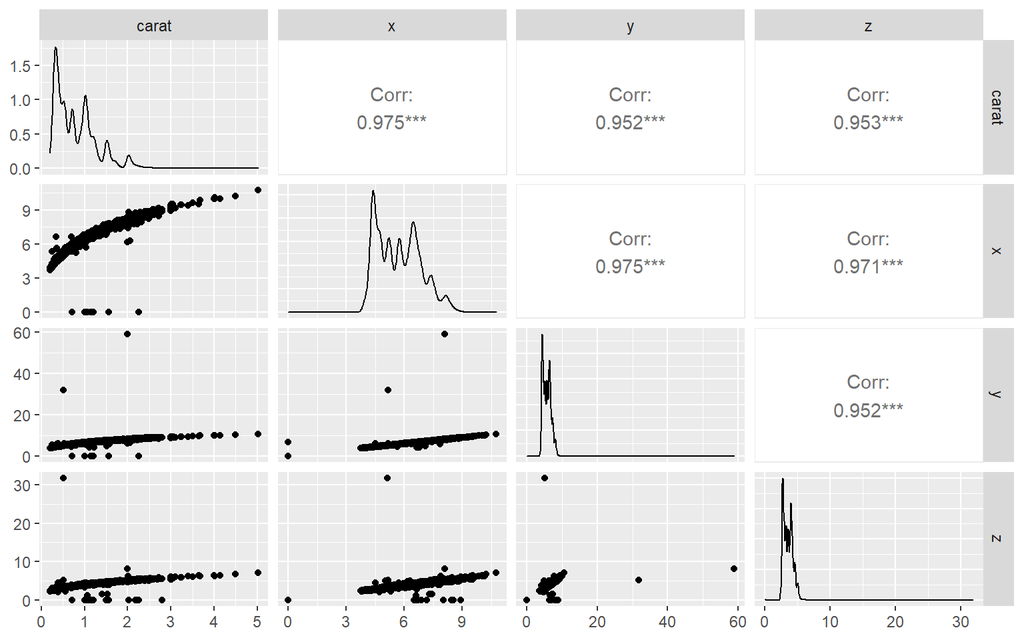

```r
ggpairs(diamond_dimension_corr)
```

## Task 3

Let’s drop columns `x`, `y` and `z` from the dataset, in preparation to use only carat going forward.

```r
diamond_minus_dimension <- diamonds %>%
  select(-x, -y, -z)

diamond_minus_dimension
```

```
## # A tibble: 53,940 x 8
##       x1 carat cut       color clarity depth table price
##    <dbl> <dbl> <chr>     <chr> <chr>   <dbl> <dbl> <dbl>
##  1     1  0.23 Ideal     E     SI2      61.5    55   326
##  2     2  0.21 Premium   E     SI1      59.8    61   326
##  3     3  0.23 Good      E     VS1      56.9    65   327
##  4     4  0.29 Premium   I     VS2      62.4    58   334
##  5     5  0.31 Good      J     SI2      63.3    58   335
##  6     6  0.24 Very Good J     VVS2     62.8    57   336
##  7     7  0.24 Very Good I     VVS1     62.3    57   336
##  8     8  0.26 Very Good H     SI1      61.9    55   337
##  9     9  0.22 Fair      E     VS2      65.1    61   337
## 10    10  0.23 Very Good H     VS1      59.4    61   338
## # ... with 53,930 more rows
```

## Task 4

We are interested in developing a regression model for the price of a diamond in terms of the possible predictor variables in the dataset. Use `ggpairs()` to investigate correlations between price and the predictors (this may take a while to run, don’t worry, make coffee or something).

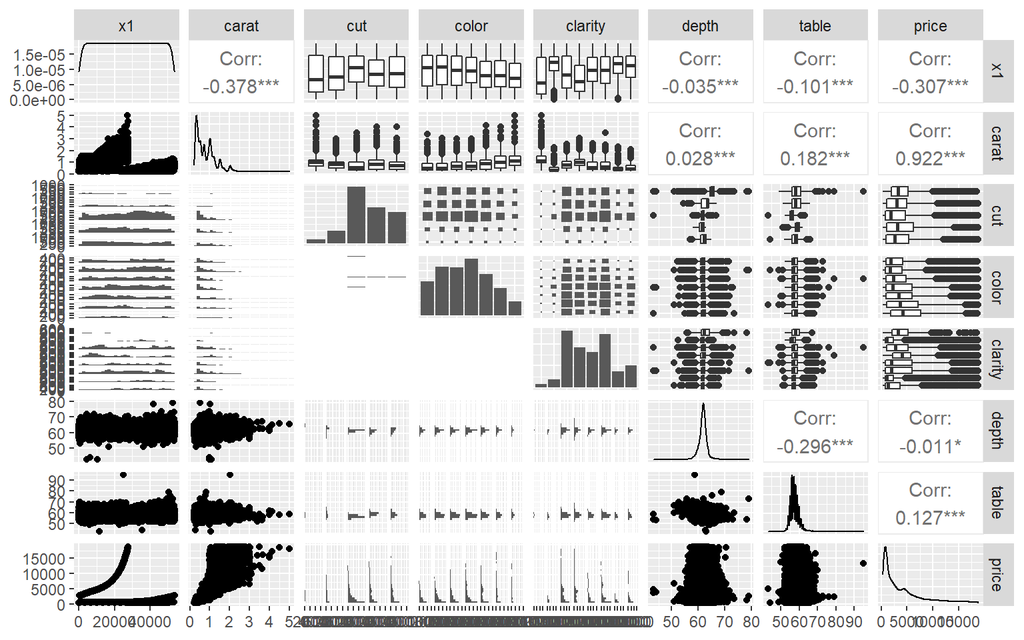

```r
ggpairs(diamond_minus_dimension)
```

### Visualisations

Perform further ggplot visualisations of any significant correlations you find.

## Task 5

Shortly we may try a regression fit using one or more of the categorical predictors `cut`, `clarity` and `color`, so let’s investigate these predictors. Investigate the levels of these predictors. How many dummy variables do you expect for each of them?

## Task 6

Start with simple linear regression. Regress price on carat and check the regression diagnostics.

## Task 7

Add another predictor of your choice. Check your assumptions, diagnostics, and interpret the model.

# Extension

## Task 8

Try adding an interaction between log(carat) and your chosen categorical predictor. Do you think this interaction term is statistically justified?

## Task 9

Find and plot an appropriate visualisation to show the effect of this interaction